# Первый этап внешнего курса

Основы информационной безопасности

Казазаев Д. М.

Российский университет дружбы народов, Москва, Россия

# Информация

## Докладчик

- Казазаев Даниил Михайлович
- Студент бакалавриата
- Российский университет дружбы народов
- [1132231427@rudn.ru]
- https://github.com/KazazaevDaniil/study_2024-2025_infosec-intro

# Вводная часть

## Материалы и методы

Внешний кур состоит из трех этапов.

## Этап первый

Первый этап курса состоит из 4 частей:

1. Базовые сетевые протоколы
2. Персонализация сети
3. Браузер TOR
4. Беспроводные сети Wi-fi

# Выполнение первого этапа внешнего курса.

# Базовые сетевые протоколы

## Базовые сетевые протоколы

HTTPS является протоколом прикладного уровня. (рис. 1])

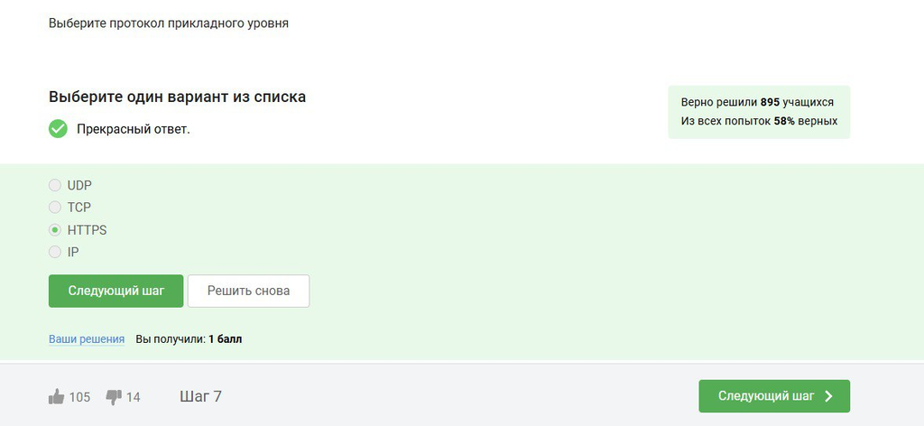

Первый вопрос

## Базовые сетевые протоколы

Протокол TCP работает на транспортном уровне. (рис. 2)

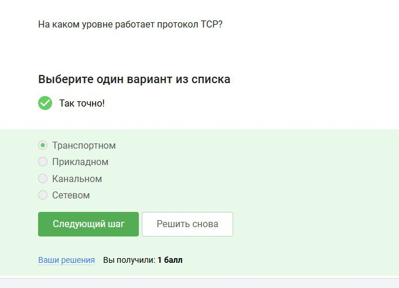

Второй вопрос

## Базовые сетевые протоколы

Адреса формата IPv4 состоят из 4-х значений от 0 до 255. (рис. 3)

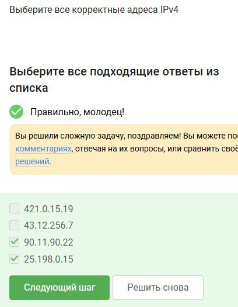

Третий вопрос

## Базовые сетевые протоколы

DNS сервера необходимы для сопоставления IP адреса с доменным именем при маршрутизации запроса. (рис. 4)

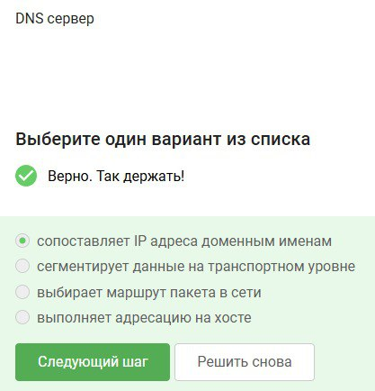

Четвертый вопрос

## Базовые сетевые протоколы

Корректная последовательность протоколов в модели TCP/IP. (рис. 5)

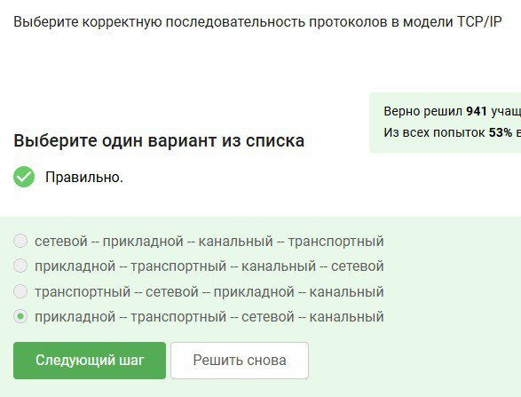

Пятый вопрос

## Базовые сетевые протоколы

Так как http это незащищенный протокол, он предполагает передачу данных в открытом виде.(рис. 6)

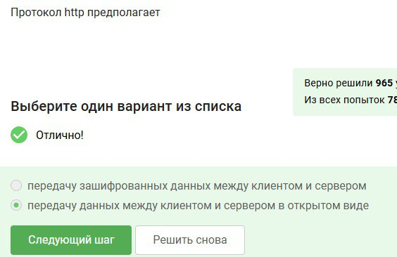

Шестой вопрос

## Базовые сетевые протоколы

HTTPS протокол состоит из двух фаз: рукопожатия и передачи данных.(рис. 7)

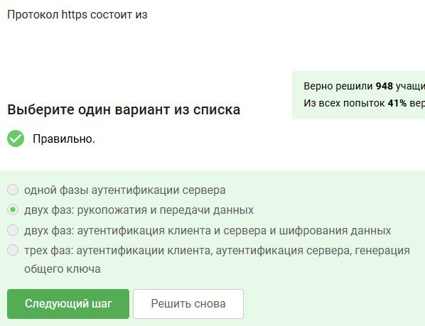

Седьмой вопрос

## Базовые сетевые протоколы

Версия протокола TLS определяется как клиентом, так и сервером на стадии “переговоров”.(рис. 8)

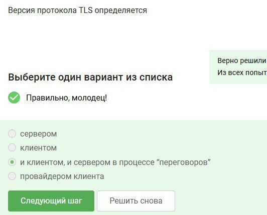

Восьмой вопрос

## Базовые сетевые протоколы

На фазе рукопожатия протокола TLS не предусмотрено шифрование данных.(рис. 9)

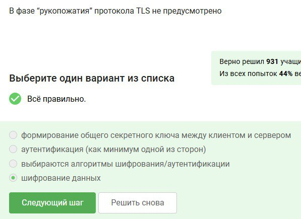

Девятый вопрос

# Персонализация сети

## Персонализация сети

Куки-файлы хранят в себе информацию о идентификаторе пользователя и id сессии.(рис. 10)

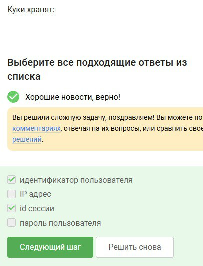

Первый вопрос

## Персонализация сети

Куки-файлы не используются для улучшения надежности соединения. (рис. 11)

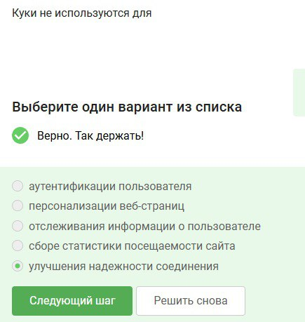

Второй вопрос

## Персонализация сети

Куки-файлы генерируются сервером. (рис. 12)

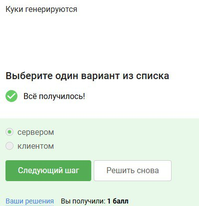

Третий вопрос

## Персонализация сети

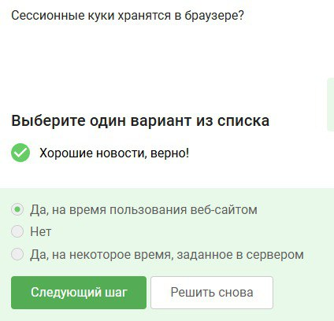

Четвертый вопрос

# Браузер TOR

## Браузер TOR

В браузере на основе TOR три промежуточных узла: охранный, промежуточный, выходной. (рис. 14)

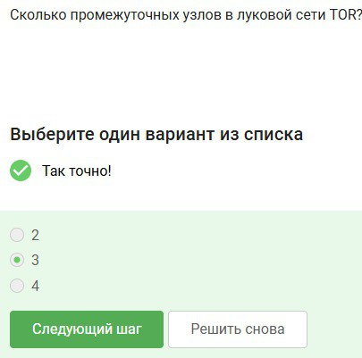

Первый вопрос

## Браузер TOR

IP-адрес получателя в системе TOR изместен только отправителю и выходному узлу. (рис. 15)

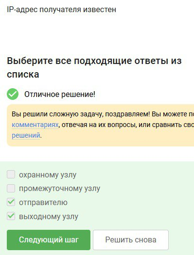

Второй вопрос

## Браузер TOR

При запросе через TOR отправитель гененирует общий секрутный ключ со всеми узлами. (рис. 16)

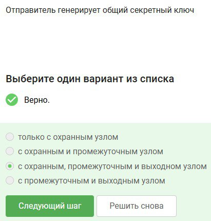

Третий вопрос

## Браузер TOR

Получатель может использовать любой браузер для принятия запроса из TOR. (рис. 17)

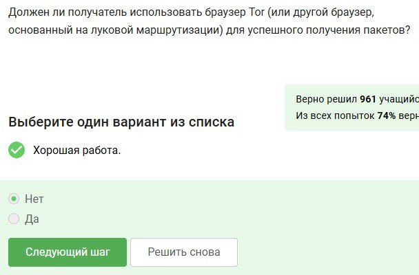

Четвертый вопрос

# Беспроводные сети Wi-fi

## Беспроводные сети Wi-fi

Wf-fi - это … (рис. 18)

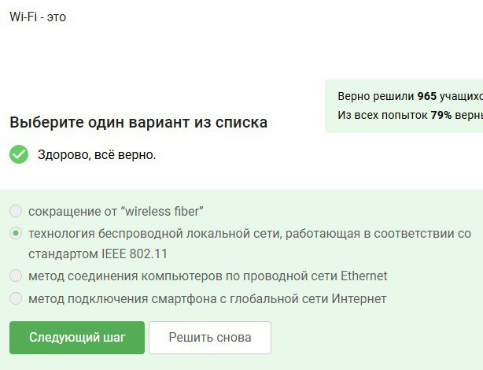

Первый вопрос

## Беспроводные сети Wi-fi

Протоколы Wf-fi работают на канальном уровне. (рис. 19)

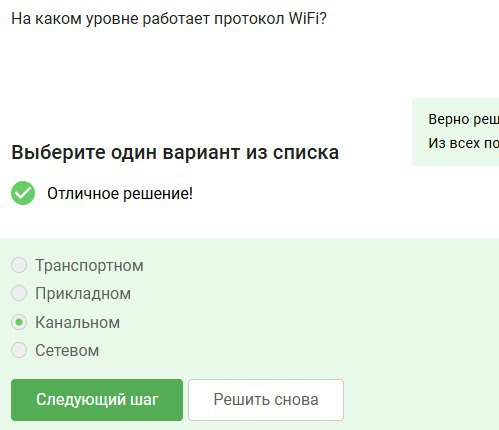

Второй вопрос

## Беспроводные сети Wi-fi

Самой небезопасный метод шифрования и аунтификации Wf-fi это WEP, так как он старый и в нем используется малое кольчество бит для шифрования. (рис. 20)

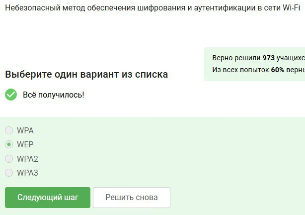

Третий вопрос

## Беспроводные сети Wi-fi

Данные шифруются после аунтификации польователя. (рис. 21)

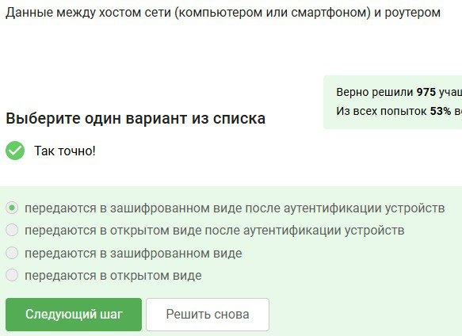

Четвертый вопрос

## Беспроводные сети Wi-fi

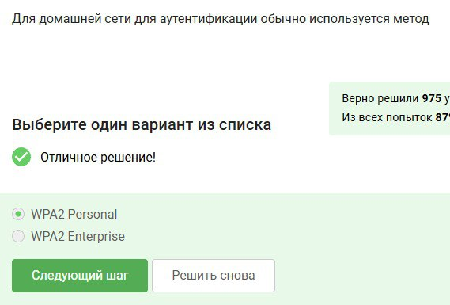

Пятый вопрос

# Вывод

Выполнен первый этап внешнего курса